# FuzzyPovertyR

```r
library(FuzzyPovertyR)
library(kableExtra)
```

## Introduction

`FuzzyPovertyR` is a package for estimating fuzzy poverty indexes. Broadly speaking, a fuzzy poverty index is an index that ranges in the set $Q=[0,1]$ (Alkire et al. (2015); Silber (2023)). A fuzzy indexes assigns to each statistical unit a value in this interval according to a given membership function (mf) $\mu(x_i)\in Q$ where $x$ is a poverty predicate. The higher the value of $\mu$, the more the individual is regarded as “poor” with respect to the poverty predicate $x$. In socio-economic surveys $x$ may be the equivalised disposable income, or expenditure. However, in principle $x$ may be a generic poverty predicate that the researcher needs to analyse, for example this could be a variable that relates to access to transports, services and other facilities.

Below we distinguish between monetary and supplementary poverty indexes (or measures). A fuzzy monetary poverty measure is calculated over a `numeric` vector of length $n$ (the available sample size). A supplementary poverty index is calculated on a `data.frame` of items of a questionnaire that relates to other dimensions of poverty other than monetary.

The dataset coming from the package is loaded in the environment with

```r
data(eusilc)
```

## Fuzzy Monetary poverty measures

The package lets the user choose among different membership functions trough the argument `fm` of the `fm_construct` function. The membership function available are:

$$\mu_i=\left(1-F_X(x_i)\right)^{\alpha-1} =
\left(\frac{\sum_{j=i+1} w_j|x_j> x_i}{\sum_{j\ge 2} w_j|x_j>
x_1}\right)^{\alpha-1}$$

where $F_X$ is the empirical cumulative distribution function of $X$ calculated for the $i-th$ individual and $w_i$ is the sampling weight of statistical unit $i$. The parameter $\alpha\ge 2$ is chosen so that the average over the function equals the head count ratio (i.e. the proportion of units whose equivalised disposable income falls below the poverty line) of the whole population.

- `fm="verma1999"` (see Betti and Verma (1999))

$$\mu_i=(1-L_X(x_i))^{\alpha-1} =
\left(\frac{\sum_{j=i+1} w_jx_j|x_j> x_i}{\sum_{j\ge 2}
w_jx_j|x_j> x_1}\right)^{\alpha-1}$$

where $L_X$ is the Lorenz Curve of $X$ calculated for the $i-th$ individual and $w_i$ is the sampling weight of statistical unit $i$. Again, the parameter $\alpha\ge 2$ is chosen once again so that the average over the function equals the head count ratio of the whole population or its estimate.

- `fm="verma"` (see Betti and Verma (2008))

$$\begin{split}
\mu_i&=\left(1-F_X(x_i)\right)^{\alpha-1}\left(1-L_X(x_i)\right)=\\
&=\left(\frac{\sum_{j=i+1} w_j|x_j> x_i}{\sum_{j\ge 2}
w_j|x_j> x_1}\right)^{\alpha-1} \left(\frac{\sum_{j=i+1}
w_jx_j|x_j> x_i}{\sum_{j\ge 2} w_jx_j|x_j> x_1}\right)
\end{split}$$

Again, the parameter $\alpha\ge 2$ is chosen once again so that the average over the function equals the head count ratio of the whole population or its estimate.

- `fm="chakravarty"` (see Chakravarty (2006))

$$\mu_i = \begin{cases}
1 & x_i = 0\\
\frac{z - x_i}{z} & 0 \le x_i < z\\
0 & x_i \ge z
\end{cases}$$
where $z$ is a threshold to be chosen by the researcher.

$$\mu_i = \begin{cases}
1, \quad 0<x_i<z_1\\
\frac{z_2-x_i}{z_2-z_1}, \quad z_1\le x_i<z_2\\
0 \quad x_i\ge z_2
\end{cases}$$

- `fm="ZBM"` (see Zedini and Belhadj (2015) and Belhadj and Matoussi (2010))

$$\mu_i = \begin{cases}
1 & a \le x_i < b\\
\frac{-x_i}{c-b} + \frac{c}{c-b} & b \le x_i < c\\
0 & x_i < a \cup x_i
\ge c\\
\end{cases}$$
where $a,c,b$ are percentiles estimated with via the bootstrap technique.

- `fm="belhadj2015"` (see Besma (2015))

$$\mu_i = \begin{cases} 1 & x_i <
z_1\\ \mu^1 = 1-\frac{1}{2}\left(\frac{x_i-z_1}{z_1}\right)^b
& z_1 \le x_i < z\\ \mu^2 = 1-\frac{1}{2}\left(\frac{z_2 -
x_i}{z_2}\right)^b & z \le x_i < z_2\\ 0 & x_i
\ge z_2 \end{cases}$$
where $z^*$ is the flex point of $\mu_i$, $z_1$ and $z_2$ have to be chosen by the researcher, and $b\ge 1$ is a shape parameter ruling the degree of convexity of the function. In particular, when $b=1$ the trend is linear.

- `fm="belhadj2011"` (see Belhadj (2011))

$$\mu_i = \begin{cases}
1 &
0 < x_i < z_{min} \\
\frac{-x_i}{z_{\max} - z_{\min}} + \frac{-z_{\max}}{z_{\max} -
z_{\min}} & z_{min} \le x_i < z_{max}\\
0 &
x_i \ge z_{max}
\end{cases}$$
where $z_{min}$ and $z_{MAX}$ have to be chosen by the researcher

For each of the functions below the `breakdown` argument can be specified in case the user’s want to obtain estimates for given sub-domains.

The computation of a fuzzy poverty index that uses the `fm="verma"`argument goes trough the following steps:

1. Estimation of the Head Count Ratio (HCR). The package `FuzzyPovertyR` provides the function `HCR` to estimate the Head Count Ratio from data. It outputs a list of three elements: a classification of units into being poor or not poor, the poverty line, and the value itself.

```r
hcr = HCR(predicate = eusilc$eq_income, weight = eusilc$DB090, p = 0.5, q = 0.6)$HCR # add poverty threshold
```

if needed, the package has a built-in function `eq_predicate` to calculate the equivalised disposable income using some equivalence scales.

3. Construction of the Fuzzy Monetary measure.

[output not shown]

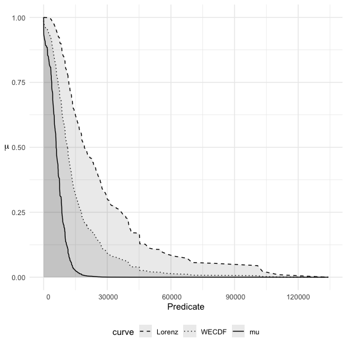

```r
verma = fm_construct(predicate = eusilc$eq_income, fm = "verma", weight = eusilc$DB090, ID = NULL, interval = c(1,10), alpha = 2)
```

The result of `fm_construct` using `fm="verma"` is a list containing

- a `data.frame` of individuals’ membership functions sorted in descending order (i.e. from most poor to least poor)

```r
head(verma$results)
```

```
#>    ID predicate    weight        mu
#> 1  44  3.225806  465.3585 1.0000000
#> 2 450  6.666667 1010.5060 0.9946732
#> 3 372 12.903226  304.7067 0.9930663
#> 4 490 17.857143 1177.4120 0.9868551
#> 5 245 20.000000  853.0255 0.9823546
#> 6 130 42.424242 1141.3410 0.9763241
```

- The estimated FM measure (note that this equals the HCR if `breakdown=NULL`). However, one can obtain estimates for sub-domains using the `breakdown` argument as follows

```r
verma.break = fm_construct(predicate = eusilc$eq_income, weight = eusilc$DB090, ID = NULL, HCR = hcr, interval = c(1,10), alpha = NULL, breakdown = eusilc$db040,
fm="verma")
```

```r
summary(verma.break)
```

```
#> Fuzzy monetary results:
#>
#>  Summary of verma membership function:
#>
#>  Quantiles:
#>
#>  0%   20%   40%   60%   80% 100%
#>   0 0.004 0.036 0.194 0.528    1
#>
#>  Estimate(s):
#>
#>     a     b     c     d     e     f     g     h     i     j     k     l     m
#> 0.189 0.165 0.166 0.268 0.217 0.178 0.363 0.294 0.186 0.155 0.157 0.272 0.327
#>     n     o     p     q     r     s     t     u     v     w     x     y     z
#> 0.247 0.237 0.255 0.356 0.163 0.375 0.076 0.509 0.242 0.206 0.271 0.313 0.213
#>
#>  Parameter(s):
#>
#> alpha
#> 3.787
```

```r
verma.break$estimate
```

```
#>          a          b          c          d          e          f          g
#> 0.18866339 0.16538025 0.16562162 0.26821706 0.21695323 0.17829490 0.36323070
#>          h          i          j          k          l          m          n
#> 0.29418642 0.18600937 0.15484057 0.15722022 0.27162839 0.32717227 0.24665062
#>          o          p          q          r          s          t          u
#> 0.23685247 0.25459850 0.35638295 0.16349880 0.37543084 0.07613034 0.50897058
#>          v          w          x          y          z
#> 0.24174548 0.20595260 0.27131691 0.31315140 0.21313753
```

- The `alpha` parameter.

```r
alpha = verma$parameters$alpha
alpha
```

```
#> [1] 2
```

With almost identical procedures is also possible to compute the index for `fm="verma1999"` and `fm="TFR"`.

```
#> [1] "verma1999"
#> [1] "FuzzyMonetary"
#> Fuzzy monetary results:
#>
#>  Summary of verma1999 membership function:
#>
#>  Quantiles:
#>
#>  0% 20%   40%   60%   80% 100%
#>   0   0 0.006 0.131 0.591    1
#>
#>  Estimate(s):
#>
#> [1] 0.246
#>
#>  Parameter(s):
#>
#>  alpha
#> 12.067
```

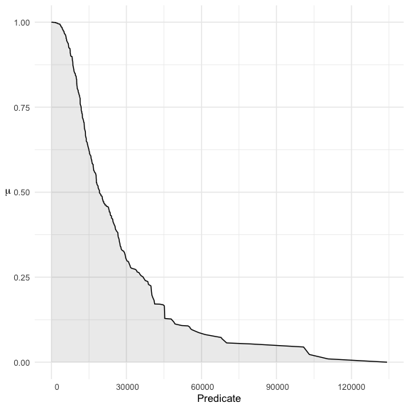

```
#> [1] "TFR"
#> [1] "FuzzyMonetary"
#> Fuzzy monetary results:
#>
#>  Summary of TFR membership function:
#>
#>  Quantiles:
#>
#>  0%   20%   40%   60%  80% 100%
#>   0 0.005 0.042 0.199 0.52    1
#>
#>  Estimate(s):
#>
#> [1] 0.246
#>
#>  Parameter(s):
#>
#> alpha
#> 3.062
```

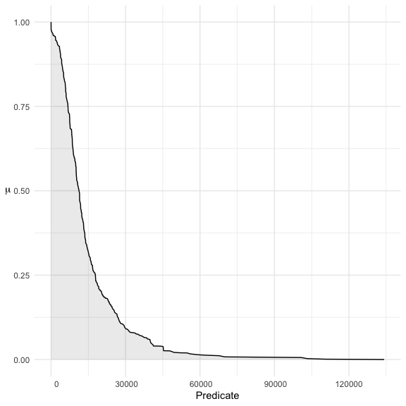

### Example using `fm=belhadj2015` and `fm=cerioli`

The construction of a fuzzy index using the membership function as Besma (2015) or Cerioli and Zani (1990) is obtained by specifying `fm="belhadj2015"` or `fm="cerioli"`. Let us begin by `fm="belhadj2015"`. For this mf the arguments `z1`, `z2` and `b` need user’s specification. The value `z` that correspond to the flex points of the mf or to the point where the two mf touch together is calculated by the function.

The parameter `b` $(>=1)$ rules the shape of the membership functions (set `b=1` for linearity)

```r
z1 = 20000; z2 = 70000; b = 2
belhadj = fm_construct(predicate = eusilc$eq_income, weight = eusilc$DB090, fm = "belhadj2015", z1 = z1, z2 = z2, b = b)
```

```
#> Fuzzy monetary results:
#>
#>  Summary of belhadj2015 membership function:
#>
#>  Quantiles:
#>
#>  0%   20% 40% 60% 80% 100%
#>   0 0.991   1   1   1    1
#>
#>  Estimate(s):
#>
#> [1] 0.939
#>
#>  Parameter(s):
#>
#>       z1       z2        z        b
#> 20000.00 70000.00 47547.17     2.00
```

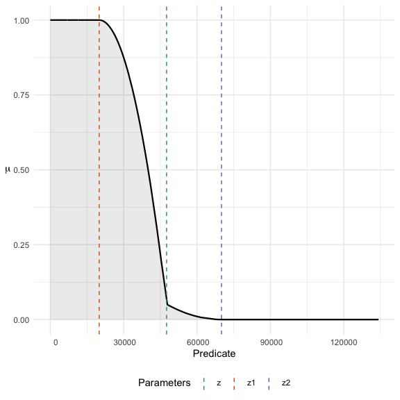

Using `fm="cerioli"`. Again we have to set the values of `z1`, `z2` as follows:

```r
z1 = 10000; z2 = 70000
cerioli = fm_construct(predicate = eusilc$eq_income, weight = eusilc$DB090, fm = "cerioli", z1 = z1, z2 = z2)
```

```
#> Fuzzy monetary results:
#>
#>  Summary of cerioli membership function:
#>
#>  Quantiles:
#>
#>  0%   20%   40% 60% 80% 100%
#>   0 0.788 0.935   1   1    1
#>
#>  Estimate(s):
#>
#> [1] 0.895
#>
#>  Parameter(s):
#>
#>    z1    z2
#> 10000 70000
```

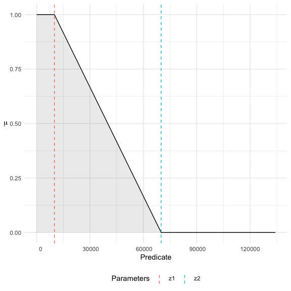

### Example using `fm=chakravarty` and `fm=belhadj2011`

Chakravarty (2006) fuzzy index is obtained setting `fm = "chakravarty"`. The argument `z` needs user’s specification as follows:

```r
z = 60000
chakravarty = fm_construct(predicate = eusilc$eq_income, weight = eusilc$DB090, fm = "chakravarty", z = z)
```

```
#> Fuzzy monetary results:
#>
#>  Summary of chakravarty membership function:
#>
#>  Quantiles:
#>
#>  0%   20%   40%  60%   80% 100%
#>   0 0.622 0.768 0.84 0.903    1
#>
#>  Estimate(s):
#>
#> [1] 0.761
#>
#>  Parameter(s):
#>
#>     z
#> 60000
```

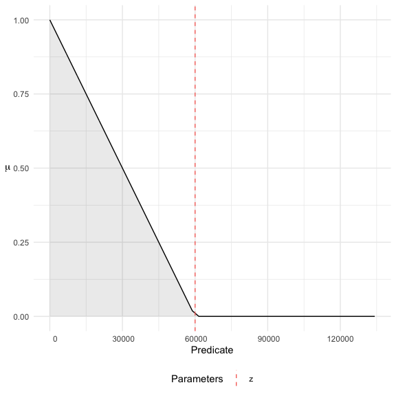

again is is possible to specify the `breakdown` argument to obtain estimates at sub-domains.

```r
chakravarty.break = fm_construct(predicate = eusilc$eq_income, eusilc$DB090, fm = "chakravarty", z = z, breakdown = eusilc$db040)
```

```r
knitr::kable(data.frame(verma.break$estimate, chakravarty.break$estimate), col.names = c("Verma", "Chakravarty"), digits = 4)
```

|  | Verma | Chakravarty |
| --- | --- | --- |
| a | 0.1887 | 0.7041 |
| b | 0.1654 | 0.7340 |
| c | 0.1656 | 0.6114 |
| d | 0.2682 | 0.7740 |
| e | 0.2170 | 0.7886 |
| f | 0.1783 | 0.6871 |
| g | 0.3632 | 0.8167 |
| h | 0.2942 | 0.8128 |
| i | 0.1860 | 0.7439 |
| j | 0.1548 | 0.7600 |
| k | 0.1572 | 0.7827 |
| l | 0.2716 | 0.8143 |
| m | 0.3272 | 0.7918 |
| n | 0.2467 | 0.7797 |
| o | 0.2369 | 0.7523 |
| p | 0.2546 | 0.7596 |
| q | 0.3564 | 0.8127 |
| r | 0.1635 | 0.7804 |
| s | 0.3754 | 0.8489 |
| t | 0.0761 | 0.7434 |
| u | 0.5090 | 0.8221 |
| v | 0.2417 | 0.7170 |
| w | 0.2060 | 0.6673 |
| x | 0.2713 | 0.8170 |
| y | 0.3132 | 0.7286 |
| z | 0.2131 | 0.7966 |

Instead, for `fm = "belhadj2011"` the values of $z_{min}$ and $z_{MAX}$ need user’s specification as follows:

```r
zmin = 5000; zmax = 60000

belhadj2011 = fm_construct(predicate = eusilc$eq_income, weight = eusilc$DB090, fm =                           "belhadj2011", z_min = zmin, z_max = zmax)
```

```
#> Fuzzy monetary results:
#>
#>  Summary of belhadj2011 membership function:
#>
#>  Quantiles:
#>
#>  0%   20%   40%   60%   80% 100%
#>   0 0.678 0.838 0.916 0.985    1
#>
#>  Estimate(s):
#>
#> [1] 0.823
#>
#>  Parameter(s):
#>
#> z_min z_max
#>  5000 60000
```

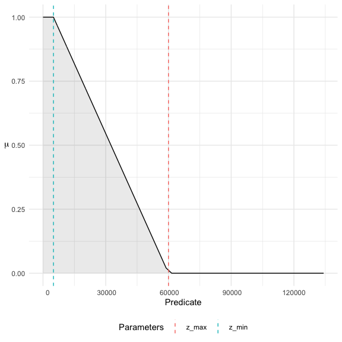

### Example using `fm=ZBM`

As previously showed to compute the index related to this mf is necessary to compute three parameters $a, b, c$ which are computed with bootstrap techniques (Zedini and Belhadj (2015)). Moreover the definition of the index require the knowledge of the household size. The index is obtained as follows:

```r
ZBM = fm_construct(predicate = eusilc$eq_income, weight = eusilc$DB090, fm =                           "ZBM", hh.size = eusilc$ncomp)
```

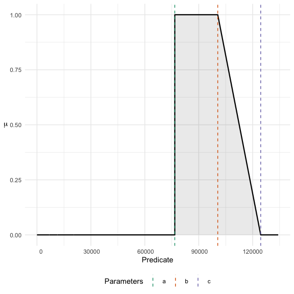

## Fuzzy supplementary

The package include also a multidimensional fuzzy poverty index known as Fuzzy Supplementary (FS) index (see Betti and Verma (2008) and Betti, Gagliardi, and Verma (2018)). This index is defined with multiple steps. The package has an ad-hoc function for each step (excluding the third one). The steps are:

- Step 1 - Identification
- Step 2 - Transformation
- Step 3 - Factor analysis to identify dimensions of poverty
- Step 4 - Calculation of weights
- Step 5 - Calculation of scores in dimensions
- Step 6 - Calculation of the $\alpha$ parameter
- Step 7 - Construction of the FS measure for each dimension

### Step 1 - Identification

This step is pretty simple. The user has to select the columns of the data that correspond to the items that he/she has decided to keep in the analysis.

Step 1 is done with the following selection

```r
# eusilc = na.omit(eusilc)
step1 = eusilc[,4:23]
```

If the data in the dataset are not “ordered” in the right way, i.e. the highest values represents the highest deprivation it is possible to invert them using the following function:

```r
#Create a dataframe in which the variable X is not ordered in the right way:
data=data.frame("X"=rep(c(1,2,3,4),20), "Y"=rep(c(7,8,9,1),20))

#Crete vec_order a vector of length n with TRUE or FALSE. True if the order of the variable is to be inverted, False otherwise

vec_order=c(TRUE,FALSE)

head(fs_order(data=data, vec_order))
```

```
#>   X Y
#> 1 4 7
#> 2 3 8
#> 3 2 9
#> 4 1 1
#> 5 4 7
#> 6 3 8
```

### Step 2 - Transformation

In this step the items are mapped from their original space to the $[0,1]$ interval using the function `fs_transform` (see Betti, Gagliardi, and Verma (2018) and Betti and Verma (2008)). For each item, a positive score $s_{ij}$ is determined as follows

$$s_{ij}= 1- d_{ij} = 1-\frac{1-F(c_{ij})}{1-F(1)},\quad i=1,\dots,n \quad
\text{and}\quad j=1,\dots,k$$

where $c_{ij}$ is the value of the category of the $j$-th item for the $i$-th household and $F(c_{ij})$ is the value of the $j$-th item cumulative function for the $i$-th household. This step is done as follows using the function `fs_transform`:

```r
step2 = fs_transform(step1, weight = eusilc$DB090, ID = eusilc$ID); class(step2)
```

```
#> [1] "FuzzySupplementary"
```

```r
summary(step2$step2)
```

```
#>        ID            HS040           HS050           HS060
#>  Min.   :  1.0   Min.   :0.000   Min.   :0.000   Min.   :0.000
#>  1st Qu.:125.8   1st Qu.:0.000   1st Qu.:1.000   1st Qu.:0.000
#>  Median :250.5   Median :1.000   Median :1.000   Median :1.000
#>  Mean   :250.5   Mean   :0.608   Mean   :0.976   Mean   :0.538
#>  3rd Qu.:375.2   3rd Qu.:1.000   3rd Qu.:1.000   3rd Qu.:1.000
#>  Max.   :500.0   Max.   :1.000   Max.   :1.000   Max.   :1.000
#>      HS070            HS080            HS090            HS100
#>  Min.   :0.0000   Min.   :0.0000   Min.   :0.0000   Min.   :0.0000
#>  1st Qu.:1.0000   1st Qu.:1.0000   1st Qu.:0.0000   1st Qu.:1.0000
#>  Median :1.0000   Median :1.0000   Median :1.0000   Median :1.0000
#>  Mean   :0.9929   Mean   :0.9874   Mean   :0.7279   Mean   :0.9758
#>  3rd Qu.:1.0000   3rd Qu.:1.0000   3rd Qu.:1.0000   3rd Qu.:1.0000
#>  Max.   :1.0000   Max.   :1.0000   Max.   :1.0000   Max.   :1.0000
#>      HS110            HS120            HS160          HS170
#>  Min.   :0.0000   Min.   :0.0000   Min.   :0.00   Min.   :0.000
#>  1st Qu.:1.0000   1st Qu.:0.1201   1st Qu.:0.00   1st Qu.:0.000
#>  Median :1.0000   Median :0.3791   Median :0.00   Median :0.000
#>  Mean   :0.8274   Mean   :0.4420   Mean   :0.05   Mean   :0.122
#>  3rd Qu.:1.0000   3rd Qu.:0.7960   3rd Qu.:0.00   3rd Qu.:0.000
#>  Max.   :1.0000   Max.   :1.0000   Max.   :1.00   Max.   :1.000
#>      HS180           HS190           HH010             HH020
#>  Min.   :0.000   Min.   :0.000   Min.   :0.00000   Min.   :0.0000
#>  1st Qu.:0.000   1st Qu.:0.000   1st Qu.:0.08545   1st Qu.:0.6244
#>  Median :0.000   Median :0.000   Median :0.08545   Median :1.0000
#>  Mean   :0.058   Mean   :0.086   Mean   :0.45947   Mean   :0.8080
#>  3rd Qu.:0.000   3rd Qu.:0.000   3rd Qu.:1.00000   3rd Qu.:1.0000
#>  Max.   :1.000   Max.   :1.000   Max.   :1.00000   Max.   :1.0000
#>      HH040           HH050           HH081            HH091
#>  Min.   :0.000   Min.   :0.000   Min.   :0.0000   Min.   :0.00
#>  1st Qu.:0.000   1st Qu.:1.000   1st Qu.:1.0000   1st Qu.:1.00
#>  Median :0.000   Median :1.000   Median :1.0000   Median :1.00
#>  Mean   :0.128   Mean   :0.954   Mean   :0.9865   Mean   :0.99
#>  3rd Qu.:0.000   3rd Qu.:1.000   3rd Qu.:1.0000   3rd Qu.:1.00
#>  Max.   :1.000   Max.   :1.000   Max.   :1.0000   Max.   :1.00
#>      HX040
#>  Min.   :0.0000
#>  1st Qu.:0.1537
#>  Median :0.5762
#>  Mean   :0.5511
#>  3rd Qu.:1.0000
#>  Max.   :1.0000
```

```r
# step2.1 = fs_transform(step1, weight = eusilc$DB090, ID = eusilc$ID, depr.score = "d")
```

which outputs

```r
knitr::kable(head(step2$step2), digits = 3, align = "c", caption = "Transformed items")
```

Transformed items

| ID | HS040 | HS050 | HS060 | HS070 | HS080 | HS090 | HS100 | HS110 | HS120 | HS160 | HS170 | HS180 | HS190 | HH010 | HH020 | HH040 | HH050 | HH081 | HH091 | HX040 |
| --- | --- | --- | --- | --- | --- | --- | --- | --- | --- | --- | --- | --- | --- | --- | --- | --- | --- | --- | --- | --- |
| 1 | 0 | 1 | 0 | 1 | 1 | 1.000 | 1 | 1 | 1.000 | 0 | 0 | 0 | 0 | 1.000 | 1.000 | 0 | 1 | 1 | 1 | 0.576 |
| 2 | 0 | 0 | 0 | 1 | 1 | 0.776 | 1 | 1 | 0.796 | 0 | 0 | 0 | 0 | 0.085 | 0.080 | 0 | 0 | 1 | 1 | 0.154 |
| 3 | 0 | 1 | 1 | 1 | 1 | 1.000 | 1 | 1 | 0.796 | 0 | 0 | 0 | 0 | 0.085 | 0.080 | 1 | 1 | 1 | 1 | 0.154 |
| 4 | 1 | 1 | 1 | 1 | 1 | 0.000 | 0 | 0 | 0.120 | 0 | 1 | 0 | 1 | 0.005 | 0.624 | 0 | 1 | 1 | 1 | 1.000 |
| 5 | 1 | 1 | 0 | 1 | 1 | 1.000 | 1 | 1 | 0.379 | 0 | 0 | 0 | 0 | 0.005 | 0.624 | 0 | 1 | 1 | 1 | 1.000 |
| 6 | 0 | 1 | 0 | 1 | 1 | 1.000 | 1 | 1 | 0.379 | 0 | 0 | 0 | 0 | 0.085 | 0.080 | 0 | 1 | 1 | 1 | 0.040 |

### Step 3 - Factor Analysis

This fuzzy supplementary measure use factor analysis to undercover latent dimension in the data. There are multiple approaches to get factor analysis in R which we do not cover in this vignette, however the user can check for example the `lavaan` package. Anyways, factor analysis is not mandatory and the user may wish to undertake a different approach to undercover a latent structure in the data. Indeed, it is possible to skip factor analysis or to use a personal assignment of columns in dimensions.

Regardless of the chosen method, to go trough Step 3 the user has to specify a numeric vector of the same length of the number of items selected in Step 1 that assigns each column to a given dimension.

```r
dimensions = c(1,1,1,1,2,2,2,2,2,3,3,3,3,4,4,4,4,5,5,5)
```

### Steps 4 and 5 - Calculation of weights and measures within dimensions

In this step, the weights to be assigned to each item, belonging to a given dimension $h$, are determined separately within each dimension. Such weighting procedure takes into account of two different aspects: the dispersion of the deprivation indicator and its correlation with other deprivation indicators in the given dimension. The weight of item $j$ belonging to dimension $h$ is taken as

$$\omega_{hj}=\omega^a_{hj}\times \omega^b_{hj}, \quad h=1,\dots,H \quad
\text{and}\quad j=1,\dots,k_h$$

$\omega_{hj}^a$ is taken as proportional to the coefficient of variation of the complement to one of the positive score for the variable concerned

$$\omega^a_{hj}\propto \frac{\sigma_{s_{hj}}}{1-\bar{s}_{hj}}$$

where $\sigma_{s_{hj}}$ is the standard deviation of the deprivation score $s$ for item $j$ in dimension $h$ and $\bar s_{hj}$ its sample mean. The second factor is

$$\omega^b_{hj}\propto\Biggl(\frac{1}{1+\sum_{j=1}^{k_h}\rho_{e_{hjhj^{\ast}}}|\rho_{e_{hjhj^{\ast}}}<r^\ast_{e_{hj}}}\Biggr)\times
\Biggl(\frac{1}{1+\sum_{j=1}^{k_h}\rho_{e_{hjhj^{\ast}}}|\rho_{e_{hjhj^{\ast}}}\ge
r^\ast_{e_{hj}}}\Biggr)$$

where $\rho_{e_{hjhj^{\ast}}}$ is the kendall’s correlation coefficient between deprivation indicators corresponding to items j and $j^{\ast}$ in the $h$-dimension and $r^\ast_{e_{hj}}$ is a critical value. Aggregation over a group of items in a particular dimension is given by a weighted mean taken over the items in that dimension $s_{hi}=\sum w_{hj} s_{hj,i}/w_{hj}$, where $w_{hj}$ is the sampling weight of the $j$-th deprivation item in the $h$-th dimension. An overall score for the $i$-th individual is calculated as the un-weighted mean:

$$s_i=\frac{\sum_h s_{hi}}{H}$$
Those two steps are implemented in the package with the function `fs_weight`. It is necessary to define a value $\rho$ which is a critical value to be used for calculation of weights in the Kendall correlation matrix. If NULL, i.e. not defined, rho is set equal to the point of largest gap between the ordered set of correlation values encountered (see Betti and Verma, 2008).

```
#> [1] "FuzzySupplementary"
#> # A tibble: 20 × 5
#>    Dimension Item     w_a   w_b      w
#>        <dbl> <chr>  <dbl> <dbl>  <dbl>
#>  1         1 HS040 0.804  0.483 0.388
#>  2         1 HS050 0.157  0.688 0.108
#>  3         1 HS060 0.928  0.508 0.471
#>  4         1 HS070 0.0807 0.504 0.0407
#>  5         2 HS080 0.111  0.611 0.0677
#>  6         2 HS090 0.597  0.586 0.350
#>  7         2 HS100 0.157  0.478 0.0751
#>  8         2 HS110 0.419  0.578 0.242
#>  9         2 HS120 0.759  0.883 0.670
#> 10         3 HS160 4.36   0.807 3.52
#> 11         3 HS170 2.69   0.630 1.69
#> 12         3 HS180 4.03   0.686 2.77
#> 13         3 HS190 3.26   1.32  4.29
#> 14         4 HH010 0.986  0.929 0.916
#> 15         4 HH020 0.427  0.900 0.384
#> 16         4 HH040 2.61   0.933 2.44
#> 17         4 HH050 0.220  0.980 0.215
#> 18         5 HH081 0.105  0.553 0.0583
#> 19         5 HH091 0.101  0.590 0.0593
#> 20         5 HX040 0.624  0.903 0.563
```

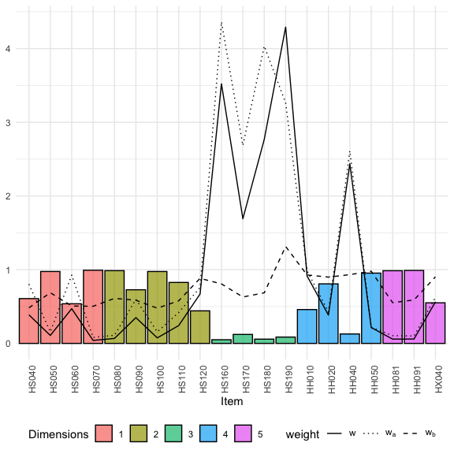

The output is a longitudinal data frame that contains the weights $w_a, w_b, w = w_a\times w_b$ , the deprivation score $s_{hi}$ for unit $i$ and dimension $j$, and the overall score $s_i$ (the average over dimensions).

```r
knitr::kable(head(steps4_5$steps4_5), digits = 4, caption = "Results from Steps 4 and 5.")
```

Results from Steps 4 and 5.

| ID | Item | s | Dimension | w_a | w_b | w | s_hi | s_i |
| --- | --- | --- | --- | --- | --- | --- | --- | --- |
| 1 | HS040 | 0 | 1 | 0.8038 | 0.4828 | 0.3881 | 0.1476 | 0.4536 |
| 2 | HS040 | 0 | 1 | 0.8038 | 0.4828 | 0.3881 | 0.0404 | 0.2703 |
| 3 | HS040 | 0 | 1 | 0.8038 | 0.4828 | 0.3881 | 0.6149 | 0.5334 |
| 4 | HS040 | 1 | 1 | 0.8038 | 0.4828 | 0.3881 | 1.0000 | 0.4972 |
| 5 | HS040 | 1 | 1 | 0.8038 | 0.4828 | 0.3881 | 0.5327 | 0.4558 |
| 6 | HS040 | 0 | 1 | 0.8038 | 0.4828 | 0.3881 | 0.1476 | 0.2527 |

### Step 6 - Calculation of the parameter $\alpha$

This step is equivalent to that discussed in the Fuzzy Monetary section when `fm="verma"`, in-fact the mf is defined as:
$$\mu_i=(1-F_S(s_i)^{\alpha-1}(1-L_S(s_i)).$$
The function `fs_equate` is used to find the value of $\alpha$ such that the expected value of the mf equals the HCR.

```r
alpha = fs_equate(steps4_5 = steps4_5, weight = eusilc$DB090, HCR = hcr, interval = c(1,10))
```

```
#> trying with alpha:  1  Expected Value:  0.5559
#> trying with alpha:  10  Expected Value:  0.0926
#> trying with alpha:  7.0204  Expected Value:  0.1285
#> trying with alpha:  4.0102  Expected Value:  0.2098
#> trying with alpha:  2.951  Expected Value:  0.2691
#> trying with alpha:  3.364  Expected Value:  0.2424
#> trying with alpha:  3.3089  Expected Value:  0.2457
#> trying with alpha:  3.3038  Expected Value:  0.246
#> trying with alpha:  3.3039  Expected Value:  0.246
#> trying with alpha:  3.3038  Expected Value:  0.246
#> Done.
```

(*alternatively a user’s defined specification of the `alpha` argument can be used as well.*)

### Step 7 - Construction of the Fuzzy Supplementary measure.

The parameter $\alpha$ estimated is used to calculate the fuzzy supplementary mf for each dimension of deprivation separately as follows. The FS indicator for the $h-th$ deprivation dimension for the $i-th$ individual is defined as combination of the $(1-F_{(S),hi})$ indicator and the $(1-L_{(S),hi})$ indicator.

$$\begin{split}
\mu_{hi}&=\biggl(1-F_{S_{h}}(s_{hi})\Biggr)^{\alpha-1}\biggl(1-L_{S_h}(s_{hi})\Biggr)=\\
&=\Biggl[\frac{\sum_{\gamma=i+1}w_{h\gamma}|s_{h\gamma}>s_{hi}}{\sum_{\gamma\ge
2}w_{h\gamma}|s_{h\gamma}>s_{h1}}\Biggr]^{\alpha-1}\Biggl[\frac{\sum_{\gamma=i+1}w_{h\gamma}s_{h\gamma}|s_{h\gamma}>s_{hi}}{\sum_{\gamma\ge
2}w_{h\gamma}s_{h\gamma}|s_{h\gamma}>s_{h1}}\Biggr]
\end{split}$$
The function `fs_construct` is used to compute the FS for each dimension and overall as follows:

```
#> Fuzzy supplementary results:
#>
#>  Summary of the membership functions:
#>
#>  Quantiles:
#>
#>         0%    25%    50%    75% 100%
#> FS1      0 0.0000 0.1028 0.3146    1
#> FS2      0 0.0234 0.1761 0.4886    1
#> FS3      0 1.0000 1.0000 1.0000    1
#> FS4      0 0.0049 0.1082 0.1082    1
#> FS5      0 0.0000 0.0113 0.3381    1
#> Overall  0 0.0074 0.0975 0.3643    1
#>
#>  Estimate(s):
#>
#>     FS1     FS2     FS3     FS4     FS5 Overall
#>   0.161   0.224   0.829   0.200   0.191   0.246
#>
#>  Parameter(s):
#>
#>  Alpha:
#>
#> [1] 3.304
#>          FS1        FS2       FS3        FS4        FS5    Overall
#> a 0.16017778 0.15721420 0.7504151 0.11843430 0.13690382 0.17803697
#> b 0.17203766 0.13353783 0.8603701 0.18226841 0.35306548 0.16150876
#> c 0.17790861 0.20949808 0.8747891 0.23864519 0.22568769 0.30225670
#> d 0.18430484 0.38429991 0.8634134 0.17047030 0.06218540 0.24525107
#> e 0.13157099 0.21602939 0.9432241 0.35550492 0.30772389 0.45379840
#> f 0.11635064 0.25468798 0.7003120 0.18457563 0.15552302 0.18651992
#> g 0.19789906 0.19517219 0.7868058 0.16063463 0.08637581 0.27243247
#> h 0.10378979 0.19398696 0.8526735 0.21615485 0.22137989 0.18955852
#> i 0.19944239 0.10733043 0.9561498 0.16923227 0.29106818 0.21228732
#> j 0.10950019 0.22043135 0.8774224 0.05680170 0.18878432 0.19766477
#> k 0.20243807 0.07183648 0.9791507 0.09036923 0.27431162 0.32986760
#> l 0.18773841 0.23105579 0.9185245 0.15254579 0.12587426 0.16756316
#> m 0.19459905 0.08661289 0.8812583 0.19715665 0.19712955 0.16909045
#> n 0.08403138 0.23751028 0.8101947 0.24143510 0.05576150 0.08021327
#> o 0.10717430 0.15153461 0.6907420 0.07810733 0.12316342 0.09665732
#> p 0.12462294 0.26074356 0.7678514 0.28953421 0.29440486 0.21144141
#> q 0.10731824 0.28134009 0.8083268 0.16137948 0.26594294 0.22523560
#> r 0.13292525 0.13075056 0.9532498 0.36621517 0.41196933 0.38421113
#> s 0.26416295 0.28100851 0.9387913 0.26507953 0.21010476 0.41753517
#> t 0.16740211 0.41950301 0.8725724 0.11691019 0.04229702 0.35450250
#> u 0.22746666 0.22160734 0.6666813 0.11469800 0.21659332 0.22168511
#> w 0.19114979 0.24834051 0.7252039 0.37794904 0.13056837 0.24049684
#> x 0.15863892 0.23342891 0.8680189 0.15527000 0.14885089 0.24134930
#> y 0.11294887 0.29472989 0.8436033 0.14557032 0.09870329 0.25374784
#> z 0.21039040 0.30499191 0.7309410 0.25553623 0.20458509 0.44289583
```

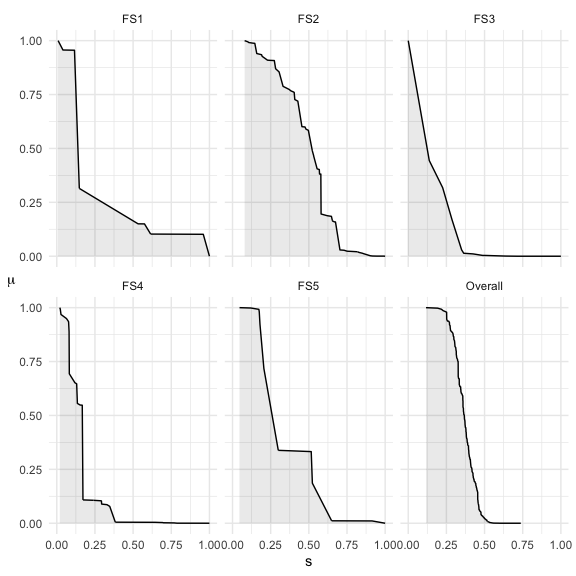

The output of the `fs_construct` function is a list containing:

- `membership` a `list` containing the FS measures for each statistical unit in the sample. Results for each dimension can be obtained by
- `estimate` the average of the membership function for each dimension

```r
FS$estimate
```

```
#>          FS1        FS2       FS3        FS4        FS5    Overall
#> a 0.16017778 0.15721420 0.7504151 0.11843430 0.13690382 0.17803697
#> b 0.17203766 0.13353783 0.8603701 0.18226841 0.35306548 0.16150876
#> c 0.17790861 0.20949808 0.8747891 0.23864519 0.22568769 0.30225670
#> d 0.18430484 0.38429991 0.8634134 0.17047030 0.06218540 0.24525107
#> e 0.13157099 0.21602939 0.9432241 0.35550492 0.30772389 0.45379840
#> f 0.11635064 0.25468798 0.7003120 0.18457563 0.15552302 0.18651992
#> g 0.19789906 0.19517219 0.7868058 0.16063463 0.08637581 0.27243247
#> h 0.10378979 0.19398696 0.8526735 0.21615485 0.22137989 0.18955852
#> i 0.19944239 0.10733043 0.9561498 0.16923227 0.29106818 0.21228732
#> j 0.10950019 0.22043135 0.8774224 0.05680170 0.18878432 0.19766477
#> k 0.20243807 0.07183648 0.9791507 0.09036923 0.27431162 0.32986760
#> l 0.18773841 0.23105579 0.9185245 0.15254579 0.12587426 0.16756316
#> m 0.19459905 0.08661289 0.8812583 0.19715665 0.19712955 0.16909045
#> n 0.08403138 0.23751028 0.8101947 0.24143510 0.05576150 0.08021327
#> o 0.10717430 0.15153461 0.6907420 0.07810733 0.12316342 0.09665732
#> p 0.12462294 0.26074356 0.7678514 0.28953421 0.29440486 0.21144141
#> q 0.10731824 0.28134009 0.8083268 0.16137948 0.26594294 0.22523560
#> r 0.13292525 0.13075056 0.9532498 0.36621517 0.41196933 0.38421113
#> s 0.26416295 0.28100851 0.9387913 0.26507953 0.21010476 0.41753517
#> t 0.16740211 0.41950301 0.8725724 0.11691019 0.04229702 0.35450250
#> u 0.22746666 0.22160734 0.6666813 0.11469800 0.21659332 0.22168511
#> w 0.19114979 0.24834051 0.7252039 0.37794904 0.13056837 0.24049684
#> x 0.15863892 0.23342891 0.8680189 0.15527000 0.14885089 0.24134930
#> y 0.11294887 0.29472989 0.8436033 0.14557032 0.09870329 0.25374784
#> z 0.21039040 0.30499191 0.7309410 0.25553623 0.20458509 0.44289583
```

- `alpha` the parameter $\alpha$ estimated from data.

Again, it is possible to obtain results for sub-domains by specifying the `breakdown` argument

[output not shown]

The package contains also a function named `fs_construct_all` which constructs the fuzzy supplementary poverty measure based without step-by-step functions.

## Variance Estimation

The variance of each Fuzzy Monetary measure can be estimated either via Bootstrap (naive or calibrated) or Jackknife Repeated Replications. We recommend the former each time the user has no knowledge of the sampling design, while we recommend the Jackknife when there is full information on the design and of the PSUs (see Betti, Gagliardi, and Verma (2018)). In the following, for the unidimensional indices, we report only the examples linked with `fm=verma`. For the other specification of the mf the function is identical the only changes are linked with the parameters required by the mf (see `fm_construct`).

### Example using `fm=verma`

In case of `fm="verma"`, we recommend the user to use the value of `alpha` from obtained from the function `fm_construct`. It is possible to specify different values of the parameter (i.e. `alpha=2`). We do not recommend to leave the argument `alpha=NULL` for the computation of variance.

```r
alpha = fm_construct(predicate = eusilc$eq_income, weight = eusilc$DB090, ID = NULL, HCR = 0.12, interval = c(1,10), alpha = NULL)$alpha
```

```r
boot.var = fm_var(predicate = eusilc$eq_income, weight = eusilc$DB090, fm = "verma",  type = "bootstrap_naive", HCR = .12, alpha = alpha, verbose = F, R = 10)

# plot(boot.var)

fm_var(predicate = eusilc$eq_income, weight = eusilc$DB090, fm = "verma", type = "jackknife", HCR = .12, alpha = 9, stratum = eusilc$stratum, psu = eusilc$psu, verbose = F)
```

```
#> $variance
#> [1] 5.324184e-06
#>
#> $type
#> [1] "jackknife"
#>
#> attr(,"class")
#> [1] "FuzzyMonetary"
```

which gives the bootstrap estimate or the jackknife estimate.

If there are multiple sub-domains or sub-populations that need variance estimation, the user can specify the breakdown to the `breakdown` argument of the function `fm_var`. For example:

```
#> Variance of Fuzzy monetary results:
#>
#>  Type of estimator:
#>
#>  bootstrap_naive
#>
#>  Estimate(s):
#>
#>        a        b        c        d        e        f        g        h
#> 0.005358 0.004356 0.005566 0.008135 0.004786 0.002813 0.013103 0.007073
#>        i        j        k        l        m        n        o        p
#> 0.003307 0.004010 0.007285 0.005158 0.009396 0.003091 0.005494 0.007515
#>        q        r        s        t        u        v        w        x
#> 0.013607 0.004333 0.006564 0.000392 0.005262 0.007323 0.007192 0.003990
#>        y        z
#> 0.009571 0.005687
#> Variance of Fuzzy monetary results:
#>
#>  Type of estimator:
#>
#>  jackknife
#>
#>  Estimate(s):
#>
#>        a        b        c        d        e        f        g        h
#> 0.006067 0.009761 0.009576 0.012358 0.013549 0.003032 0.014162 0.024544
#>        i        j        k        l        m        n        o        p
#> 0.005101 0.006252 0.014782 0.003836 0.016164 0.002989 0.008660 0.007709
#>        q        r        s        t        u        v        w        x
#> 0.022870 0.008810 0.007936 0.000672 0.008556 0.010271 0.007848 0.007644
#>        y        z
#> 0.009668 0.005607
```

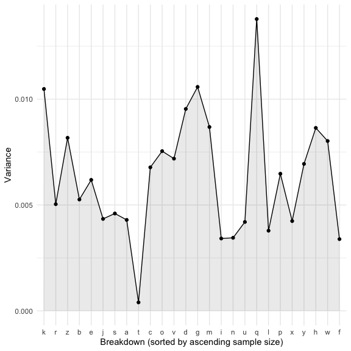

### Fuzzy supplementary

[figure not shown]

```r
variance = fs_var(data = eusilc[,4:23], weight = eusilc$DB090, ID = NULL,
                  dimensions = dimensions, breakdown = NULL, HCR = 0.12,
                  alpha = 2, rho = NULL, type = 'bootstrap_naive',
                  M = NULL, R = 50, verbose = F)
summary(variance)
```

The following uses the Jackknife

```r
fs_var(data = eusilc[,4:23], weight = eusilc$DB090, ID = NULL, dimensions = dimensions,
       stratum = eusilc$stratum, psu = eusilc$psu, verbose = F, f = .01,
       breakdown = NULL, alpha = 3, rho = NULL, type = "jackknife", fixed = T)%>%summary()
```

Alkire, Sabina, José Manuel Roche, Paola Ballon, James Foster, Maria Emma Santos, and Suman Seth. 2015. *Multidimensional Poverty Measurement and Analysis*. Oxford University Press, USA.

Belhadj, Besma. 2011. “A New Fuzzy Unidimensional Poverty Index from an Information Theory Perspective.” *Empirical Economics* 40 (3): 687–704. https://doi.org/10.1007/s00181-010-0368-5.

Belhadj, Besma, and Mohamed Salah Matoussi. 2010. “Poverty in Tunisia: A Fuzzy Measurement Approach.” *Swiss Journal of Economics and Statistics* 146 (2): 431–50.

Besma, Belhadj. 2015. “Employment Measure in Developing Countries via Minimum Wage and Poverty New Fuzzy Approach.” *Opsearch* 52: 329–39.

Betti, Gianni, Francesca Gagliardi, and Vijay Verma. 2018. “Simplified Jackknife Variance Estimates for Fuzzy Measures of Multidimensional Poverty.” *International Statistical Review* 86 (1): 68–86.

Betti, Gianni, and Vijay Verma. 1999. “Measuring the Degree of Poverty in a Dynamic and Comparative Context: A Multi-Dimensional Approach Using Fuzzy Set Theory.” In *Proceedings, Iccs-Vi*, 11:289.

———. 2008. “Fuzzy Measures of the Incidence of Relative Poverty and Deprivation: A Multi-Dimensional Perspective.” *Statistical Methods and Applications* 17: 225–50.

Cerioli, Andrea, and Sergio Zani. 1990. “A Fuzzy Approach to the Measurement of Poverty.” In *Income and Wealth Distribution, Inequality and Poverty*, 272–84. Springer.

Chakravarty, Satya R. 2006. “An Axiomatic Approach to Multidimensional Poverty Measurement via Fuzzy Sets.” *Poverty, Social Exclusion and Stochastic Dominance*, 123–41.

Cheli, Bruno, and Achille Lemmi. 1995. “A’totally’fuzzy and Relative Approach to the Multidimensional Analysis of Poverty.”

Silber, Jacques. 2023. *Research Handbook on Measuring Poverty and Deprivation*. Edward Elgar Publishing, UK.

Zedini, Asma, and Besma Belhadj. 2015. “A New Approach to Unidimensional Poverty Analysis: Application to the Tunisian Case.” *Review of Income and Wealth* 61 (3): 465–76.